## Question - How accurately can the outcome of a pass play be predicted?

Completion percentage, which is the ratio of completed passes to total number of passes attempted, is considered one of the most important statistics used to evaluate a quarterback’s performance. Of interest is predicting whether a pass is completed or not given other information about the play. This could possibly yield valuable information about which kinds of plays are easiest for the secondary to defend against.

Before performing any data analysis, the average weight, height, and age variables were converted to variables for the differences in weight, height, and age between the offense and the defense. In addition, passResult was converted to a binary response by removing plays in which a sack occurred and counting interceptions as incomplete passes. Not counting interceptions as incomplete passes would result in a class imbalance that could affect model fitting. Predicting interceptions was also seen as adding little value to the analysis. The objective is to predict whether passResult is “I” or “C” after making these modifications to the data. offensePlayResult and epa were not used as predictors, as including them would not yield any valuable information (i.e., it is highly likely that a pass was incomplete knowing the offense gained 0 yards on the play).

All of these models are very commonly used in the case of a binary classification problem. Below is a table containing the test classification rate for all 14 models.

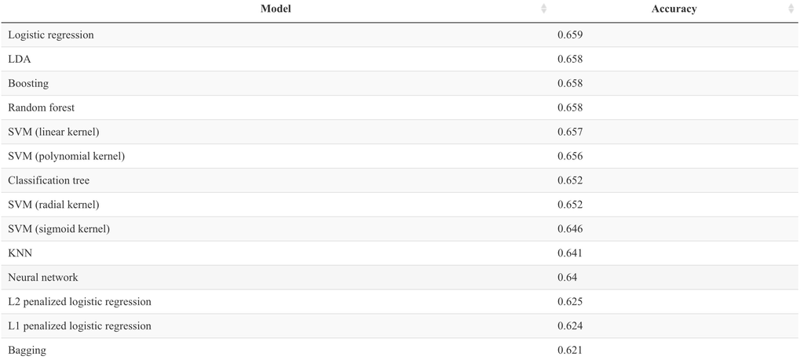

It is disappointing that a more flexible model did not perform better than logistic regression, and it is interesting that the test classification rates are so close to the percentage of completed passes in the training and test sets, which is about 65%. The classification rates are only slightly better than random guessing, so it appears that the outcome of a pass play cannot be predicted very accurately using these covariates.

Below is a variable importance plot for the best tree model, which was boosting. The importance scores for type of dropback and number of pass rushers were high for both boosting and the classification tree. The importance score for third down was high for both boosting and the classification tree as well. In comparison, the total time remaining in the game and player attributes such as age, weight, and height had high importance scores for both bagging and random forest.

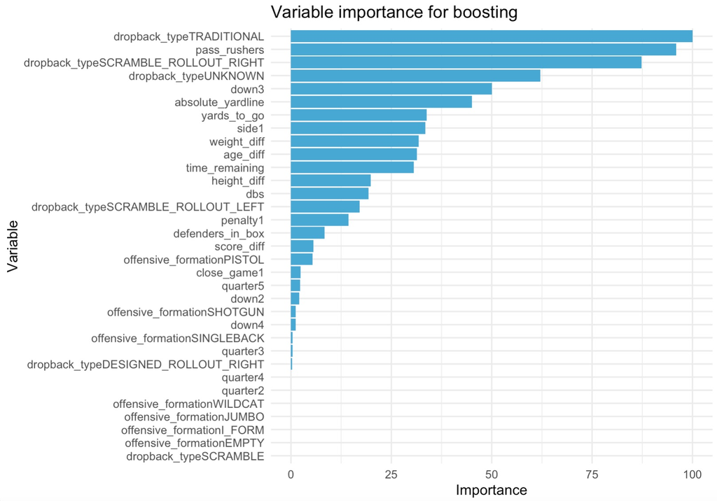

```r
library(caret)
library(DT)
library(dplyr)
library(e1071)
library(gbm)
library(ggplot2)
library(glmnet)
library(mltools)
library(nnet)

# Read in the data
train <- read.csv("NFL_Train.csv")
test <- read.csv("NFL_Test.csv")

# Create variables for the differences
train$weight_diff <- train$AvgWeightDef - train$AvgWeightOff
train$height_diff <- train$AvgHeightDef - train$AvgHeightOff
train$age_diff <- train$AvgAgeDef - train$AvgAgeOff

test$weight_diff <- test$AvgWeightDef - test$AvgWeightOff
test$height_diff <- test$AvgHeightDef - test$AvgHeightOff
test$age_diff <- test$AvgAgeDef - test$AvgAgeOff

# Filter for plays with no sacks
train <- train %>%
  filter(passResult != "S")

test <- test %>%
  filter(passResult != "S")

# Change passResult to binary
train$pass_result <- ifelse(train$passResult == "C", "1", "0")
test$pass_result <- ifelse(test$passResult == "C", "1", "0")

# Change levels of side
train$side <- ifelse(train$side == "own", "1", "0")
test$side <- ifelse(test$side == "own", "1", "0")

# Remove, rename, and reorder predictors
train <- train %>%
  select(quarter, down, "yards_to_go" = yardsToGo, "offensive_formation" = offenseFormation,
         "defenders_in_box" = defendersInTheBox, "pass_rushers" = numberOfPassRushers,
         "dropback_type" = typeDropback, "absolute_yardline" = absoluteYardlineNumber, score_diff,
         side, time_remaining, close_game, penalty, dbs, weight_diff, height_diff, age_diff,
         pass_result)

test <- test %>%
  select(quarter, down, "yards_to_go" = yardsToGo, "offensive_formation" = offenseFormation,
         "defenders_in_box" = defendersInTheBox, "pass_rushers" = numberOfPassRushers,
         "dropback_type" = typeDropback, "absolute_yardline" = absoluteYardlineNumber, score_diff,
         side, time_remaining, close_game, penalty, dbs, weight_diff, height_diff, age_diff,
         pass_result)

# Make sure the variables are of the right type
factors <- c("quarter", "down", "offensive_formation", "dropback_type", "side", "close_game",
             "penalty", "pass_result")
train[factors] <- lapply(train[factors], factor)
test[factors] <- lapply(test[factors], factor)

numerics <- c("yards_to_go", "defenders_in_box", "pass_rushers", "absolute_yardline", "score_diff",
              "time_remaining", "dbs", "weight_diff", "height_diff", "age_diff")
train[numerics] <- sapply(train[numerics], as.numeric)
test[numerics] <- sapply(test[numerics], as.numeric)

# Rename level for offensive_formation
levels(train$offensive_formation)[levels(train$offensive_formation) == ""] <- "UNKNOWN"
levels(test$offensive_formation)[levels(test$offensive_formation) == ""] <- "UNKNOWN"

### Logistic regression

# Train the model
nfl_glm <- train(pass_result ~., data = train,
                 trControl = trainControl(method = "cv", number = 5), method = "glm",
                 family = "binomial")

# Predict on the test set
nfl_glm_pred <- predict(nfl_glm, test)

# Report the confusion matrix and accuracy (0.6590515)
confusionMatrix(nfl_glm_pred, test$pass_result)
model1_acc <- mean(nfl_glm_pred == test$pass_result)

### Penalized logistic regression
train_mat <- model.matrix(pass_result ~., data = train)
test_mat <- model.matrix(pass_result ~., data = test)

## L1

# Train the model
set.seed(1)
nfl_cv1 <- cv.glmnet(train_mat, train$pass_result, alpha = 1, family = "binomial")
nfl_l1 <- glmnet(train_mat, train$pass_result, alpha = 1, family = "binomial",
                 lambda = nfl_cv1$lambda.min)

# Predict on the test set
nfl_l1_probs <- predict(nfl_l1, test_mat)
nfl_l1_pred <- ifelse(nfl_l1_probs > 0.5, "1", "0")

# Calculate the accuracy (0.6240602)
model2_acc <- mean(nfl_l1_pred == test$pass_result)

## L2

# Train the model
set.seed(1)
nfl_cv2 <- cv.glmnet(train_mat, train$pass_result, alpha = 0, family = "binomial")
nfl_l2 <- glmnet(train_mat, train$pass_result, alpha = 0, family = "binomial",
                 lambda = nfl_cv2$lambda.min)

# Predict on the test set
nfl_l2_probs <- predict(nfl_l2, test_mat)
nfl_l2_pred <- ifelse(nfl_l2_probs > 0.5, "1", "0")

# Calculate the accuracy (0.6249277)
model3_acc <- mean(nfl_l2_pred == test$pass_result)

### LDA

# Train the model
nfl_lda <- train(pass_result ~., data = train, trControl = trainControl(method = "cv", number = 10),
                 method = "lda")

# Predict on the test set
nfl_lda_pred <- predict(nfl_lda, test)

# Report the confusion matrix and accuracy (0.6581839)
confusionMatrix(nfl_lda_pred, test$pass_result)
model4_acc <- mean(nfl_lda_pred == test$pass_result)

### KNN

# Train the classifier and calculate the training accuracy for a range of K
train_control <- trainControl(method = "cv", number = 10)

set.seed(1)
knn_accuracy = rep(NA, 15)
for (i in 1:15) {
  knn = train(pass_result ~., data = train, method = "knn", trControl = train_control,
              preProcess = c("center", "scale"), tuneGrid = data.frame(k = i))
  knn_accuracy[i] = as.numeric(knn$results[2])
}
knn_accuracy

# Refit the model using K = 15
set.seed(1)
nfl_knn <- train(pass_result ~., data = train, method = "knn", trControl = train_control,
                 preProcess = c("center", "scale"), tuneGrid = data.frame(k = 15))

# Predict on the test set
nfl_knn_pred <- predict(nfl_knn, test)

# Report the confusion matrix and accuracy (0.6414112)
confusionMatrix(nfl_knn_pred, test$pass_result)
model5_acc <- mean(nfl_knn_pred == test$pass_result)

### Trees

## Classification tree

# Train the model
set.seed(1)
nfl_tree <- train(pass_result ~., data = train, method = "rpart", trControl = train_control, tuneLength = 10)

# Predict on the test set
nfl_tree_pred <- predict(nfl_tree, test)

# Report the confusion matrix and accuracy (0.652111)
confusionMatrix(nfl_tree_pred, test$pass_result)
model6_acc <- mean(nfl_tree_pred == test$pass_result)

# Produce a variable importance plot
varImp(nfl_tree)

## Bagging

# Train the model
set.seed(1)
nfl_bag <- train(pass_result ~., data = train, method = "treebag", trControl = train_control)

# Predict on the test set
nfl_bag_pred <- predict(nfl_bag, test)

# Report the confusion matrix and accuracy (0.6211683)
confusionMatrix(nfl_bag_pred, test$pass_result)
model7_acc <- mean(nfl_bag_pred == test$pass_result)

# Produce a variable importance plot
varImp(nfl_bag)

## Boosting

# Specify a grid of tuning parameters
boost_grid <- expand.grid(interaction.depth = c(1, 5), n.trees = c(500, 1500), shrinkage = 0.01,
                          n.minobsinnode = 20)

# Train the model
set.seed(1)
nfl_boost <- train(pass_result ~., data = train, method = "gbm", trControl = train_control, tuneGrid = boost_grid,
                   verbose = FALSE)

# Predict on the test set
nfl_boost_pred <- predict(nfl_boost, test)

# Report the confusion matrix and accuracy (0.6578947)
confusionMatrix(nfl_boost_pred, test$pass_result)
model8_acc <- mean(nfl_boost_pred == test$pass_result)

# Produce a variable importance plot
nfl_boost_imp <- as.data.frame(varImp(nfl_boost)$importance)
nfl_boost_imp$Variable <- as.factor(rownames(nfl_boost_imp))
rownames(nfl_boost_imp) <- NULL

ggplot(data = nfl_boost_imp, aes(x = reorder(Variable, Overall), y = Overall)) + geom_bar(stat = "identity", fill = "#48a8d4") +
  labs(x = "Variable", y = "Importance", title = "Variable importance for boosting") + coord_flip() + theme_minimal()

## Random forest

# Specify a grid of tuning parameters
rf_grid <- expand.grid(mtry = c(1, 3, 5), splitrule = "gini", min.node.size = c(1, 5))

# Train the model
set.seed(1)
nfl_rf <- train(pass_result ~., data = train, method = "ranger", trControl = train_control, tuneGrid = rf_grid,
                importance = "impurity")

# Predict on the test set
nfl_rf_pred <- predict(nfl_rf, test)

# Report the confusion matrix and accuracy (0.6578947)
confusionMatrix(nfl_rf_pred, test$pass_result)
model9_acc <- mean(nfl_rf_pred == test$pass_result)

# Produce a variable importance plot
varImp(nfl_rf)

### Support vector machines

## Linear kernel

# Train the model
set.seed(1)
nfl_svm1 <- tune(svm, pass_result ~., data = train, kernel = "linear", ranges = list(cost = c(0.01, 0.1, 1)))

# Predict on the test set
nfl_svm_pred1 <- predict(nfl_svm1$best.model, test)

# Report the confusion matrix and accuracy (0.6573164)
nfl_svm_cm1 <- table(nfl_svm_pred1, test$pass_result)
model10_acc <- sum(diag(nfl_svm_cm1)) / sum(nfl_svm_cm1)

## Polynomial kernel

# Train the model
set.seed(1)
nfl_svm2 <- tune(svm, pass_result ~., data = train, kernel = "polynomial", ranges = list(cost = c(0.01, 1),
                                                                                         degree = c(2, 3)))
# Predict on the test set
nfl_svm_pred2 <- predict(nfl_svm2$best.model, test)

# Report the confusion matrix and accuracy (0.6558704)
nfl_svm_cm2 <- table(nfl_svm_pred2, test$pass_result)
model11_acc <- sum(diag(nfl_svm_cm2)) / sum(nfl_svm_cm2)

## Radial kernel

# Train the model
set.seed(1)
nfl_svm3 <- tune(svm, pass_result ~., data = train, kernel = "radial", ranges = list(cost = c(0.01, 1),
                                                                                     gamma = c(0.01, 1)))

# Predict on the test set
nfl_svm_pred3 <- predict(nfl_svm3$best.model, test)

# Report the confusion matrix and accuracy (0.652111)
nfl_svm_cm3 <- table(nfl_svm_pred3, test$pass_result)
model12_acc <- sum(diag(nfl_svm_cm3)) / sum(nfl_svm_cm3)

## Sigmoid kernel

# Train the model
set.seed(1)
nfl_svm4 <- tune(svm, pass_result ~., data = train, kernel = "sigmoid", ranges = list(cost = c(0.01, 1),
                                                                                      gamma = c(0.01, 1)))

# Predict on the test set
nfl_svm_pred4 <- predict(nfl_svm4$best.model, test)

# Report the confusion matrix and accuracy (0.6463274)
nfl_svm_cm4 <- table(nfl_svm_pred4, test$pass_result)
model13_acc <- sum(diag(nfl_svm_cm4)) / sum(nfl_svm_cm4)

### Neural network

# Convert all categorical variables to dummies through one-hot encoding
train_nn <- one_hot(as.data.table(train), cols = factors)
train_nn$pass_result_0 <- NULL
train_nn$pass_result_1 <- NULL
train_nn <- cbind(train_nn, "pass_result" = train$pass_result)
train_nn <- as.data.frame(train_nn)

test_nn <- one_hot(as.data.table(test), cols = factors)
test_nn$pass_result_0 <- NULL
test_nn$pass_result_1 <- NULL
test_nn <- cbind(test_nn, "pass_result" = test$pass_result)
test_nn <- as.data.frame(test_nn)

# Scale the numeric predictors
train_nn[numerics] <- scale(train_nn[numerics], scale = TRUE)
test_nn[numerics] <- scale(test_nn[numerics], scale = TRUE)

# Train the model
set.seed(1)
nfl_nn <- nnet(pass_result ~., data = train_nn, size = 5)

# Predict on the test set
nfl_nn_pred <- predict(nfl_nn, test_nn, type = "class")

# Report the confusion matrix and accuracy (0.6396761)
nfl_nn_cm <- table(nfl_nn_pred, test_nn$pass_result)
model14_acc <- sum(diag(nfl_nn_cm)) / sum(nfl_nn_cm)

### Summary of models

## Create a table for comparing model performance
Model <- c("Logistic regression", "L1 penalized logistic regression",
           "L2 penalized logistic regression", "LDA", "KNN", "Classification tree", "Bagging",
           "Boosting", "Random forest", "SVM (linear kernel)", "SVM (polynomial kernel)",
           "SVM (radial kernel)", "SVM (sigmoid kernel)", "Neural network")

Accuracy <- round(c(model1_acc, model2_acc, model3_acc, model4_acc, model5_acc, model6_acc, model7_acc,
              model8_acc, model9_acc, model10_acc, model11_acc, model12_acc, model13_acc, model14_acc), 3)

performance <- cbind(Model, Accuracy)
performance <- as.data.frame(performance)

performance <- performance %>%
  arrange(desc(Accuracy))

datatable(performance, rownames = FALSE)
```